# Project: NSAA

### (No-Show Appointment Analysis)

- Introduction
- Data Wrangling
- Exploratory Data Analysis
- Conclusions

## Introduction

**DATASET :** This dataset collects information from 100k medical appointments in Brazil and is focused on the question of whether or not patients show up for their appointment. A number of characteristics about the patient are included in each row.

- ‘ScheduledDay’ tells us on what day the patient set up their appointment.
- ‘Neighborhood’ indicates the location of the hospital.
- ‘Scholarship’ indicates whether or not the patient is enrolled in Brasilian welfare program Bolsa Família.
- Be careful about the encoding of the last column: it says ‘No’ if the patient showed up to their appointment, and ‘Yes’ if they did not show up.

### Questions:

- What factors are important for us to know in order to predict if a patient will show up for their scheduled appointment?
- Does age play a role in No-Show?
- Does gender play a role?
- Does location play a role?

### Importing Necessary Packages

```python
import pandas as pd
import numpy as np
import matplotlib.pyplot as plt
import seaborn as sns
import datetime as dt
%matplotlib inline
```

## Data Wrangling

> In this section of the report, we will load in the data, check for cleanliness, and then trim and clean the dataset for analysis.

```python
df=pd.read_csv('noshowapmnt.csv')
df.head(3)
```

|  | PatientId | AppointmentID | Gender | ScheduledDay | AppointmentDay | Age | Neighbourhood | Scholarship | Hipertension | Diabetes | Alcoholism | Handcap | SMS_received | No-show |
| --- | --- | --- | --- | --- | --- | --- | --- | --- | --- | --- | --- | --- | --- | --- |
| 0 | 2.987250e+13 | 5642903 | F | 2016-04-29T18:38:08Z | 2016-04-29T00:00:00Z | 62 | JARDIM DA PENHA | 0 | 1 | 0 | 0 | 0 | 0 | No |
| 1 | 5.589978e+14 | 5642503 | M | 2016-04-29T16:08:27Z | 2016-04-29T00:00:00Z | 56 | JARDIM DA PENHA | 0 | 0 | 0 | 0 | 0 | 0 | No |
| 2 | 4.262962e+12 | 5642549 | F | 2016-04-29T16:19:04Z | 2016-04-29T00:00:00Z | 62 | MATA DA PRAIA | 0 | 0 | 0 | 0 | 0 | 0 | No |

> Loads the dataset and displays first three values of dataset

```python
df.shape
```

```
(110527, 14)
```

> Shows the number of column and row in the dataset

```python
df.info()
```

```
<class 'pandas.core.frame.DataFrame'>
RangeIndex: 110527 entries, 0 to 110526
Data columns (total 14 columns):
PatientId         110527 non-null float64
AppointmentID     110527 non-null int64
Gender            110527 non-null object
ScheduledDay      110527 non-null object
AppointmentDay    110527 non-null object
Age               110527 non-null int64
Neighbourhood     110527 non-null object
Scholarship       110527 non-null int64
Hipertension      110527 non-null int64
Diabetes          110527 non-null int64
Alcoholism        110527 non-null int64
Handcap           110527 non-null int64
SMS_received      110527 non-null int64
No-show           110527 non-null object
dtypes: float64(1), int64(8), object(5)
memory usage: 11.8+ MB
```

> Shows the columns and thier datatype

```python
print(df.isnull().sum())
```

```
PatientId         0
AppointmentID     0
Gender            0
ScheduledDay      0
AppointmentDay    0
Age               0
Neighbourhood     0
Scholarship       0
Hipertension      0
Diabetes          0
Alcoholism        0
Handcap           0
SMS_received      0
No-show           0
dtype: int64
```

> It checks if our dataset contains any null value

```python
df.nunique()
```

```
PatientId          62299
AppointmentID     110527
Gender                 2
ScheduledDay      103549
AppointmentDay        27
Age                  104
Neighbourhood         81
Scholarship            2
Hipertension           2
Diabetes               2
Alcoholism             2
Handcap                5
SMS_received           2
No-show                2
dtype: int64
```

> It checks for Number of Unique values per columns

```python
df.describe()
```

|  | PatientId | AppointmentID | Age | Scholarship | Hipertension | Diabetes | Alcoholism | Handcap | SMS_received |
| --- | --- | --- | --- | --- | --- | --- | --- | --- | --- |
| count | 1.105270e+05 | 1.105270e+05 | 110527.000000 | 110527.000000 | 110527.000000 | 110527.000000 | 110527.000000 | 110527.000000 | 110527.000000 |
| mean | 1.474963e+14 | 5.675305e+06 | 37.088874 | 0.098266 | 0.197246 | 0.071865 | 0.030400 | 0.022248 | 0.321026 |
| std | 2.560949e+14 | 7.129575e+04 | 23.110205 | 0.297675 | 0.397921 | 0.258265 | 0.171686 | 0.161543 | 0.466873 |
| min | 3.921784e+04 | 5.030230e+06 | -1.000000 | 0.000000 | 0.000000 | 0.000000 | 0.000000 | 0.000000 | 0.000000 |
| 25% | 4.172614e+12 | 5.640286e+06 | 18.000000 | 0.000000 | 0.000000 | 0.000000 | 0.000000 | 0.000000 | 0.000000 |
| 50% | 3.173184e+13 | 5.680573e+06 | 37.000000 | 0.000000 | 0.000000 | 0.000000 | 0.000000 | 0.000000 | 0.000000 |
| 75% | 9.439172e+13 | 5.725524e+06 | 55.000000 | 0.000000 | 0.000000 | 0.000000 | 0.000000 | 0.000000 | 1.000000 |
| max | 9.999816e+14 | 5.790484e+06 | 115.000000 | 1.000000 | 1.000000 | 1.000000 | 1.000000 | 4.000000 | 1.000000 |

> It observes minimum, maximum and mean value of numric-valued columns

## Data Cleaning :

```python
df.rename(columns=lambda x: x.strip().lower(),inplace=True)
df.rename(columns={"handcap":"handicap","hipertension":"hypertension","no-show":"no_show"},inplace=True)
df.info()
```

```
<class 'pandas.core.frame.DataFrame'>
RangeIndex: 110527 entries, 0 to 110526
Data columns (total 14 columns):
patientid         110527 non-null float64
appointmentid     110527 non-null int64
gender            110527 non-null object
scheduledday      110527 non-null object
appointmentday    110527 non-null object
age               110527 non-null int64
neighbourhood     110527 non-null object
scholarship       110527 non-null int64
hypertension      110527 non-null int64
diabetes          110527 non-null int64
alcoholism        110527 non-null int64
handicap          110527 non-null int64
sms_received      110527 non-null int64
no_show           110527 non-null object
dtypes: float64(1), int64(8), object(5)
memory usage: 11.8+ MB
```

> It Renames column name to lower letter,Correctes Spelling and replace dash to underscore

```python
df['patientid'] = df['patientid'].astype(int)
df.info()
```

```
<class 'pandas.core.frame.DataFrame'>
RangeIndex: 110527 entries, 0 to 110526
Data columns (total 14 columns):
patientid         110527 non-null int64
appointmentid     110527 non-null int64
gender            110527 non-null object
scheduledday      110527 non-null object
appointmentday    110527 non-null object
age               110527 non-null int64
neighbourhood     110527 non-null object
scholarship       110527 non-null int64
hypertension      110527 non-null int64
diabetes          110527 non-null int64
alcoholism        110527 non-null int64
handicap          110527 non-null int64
sms_received      110527 non-null int64
no_show           110527 non-null object
dtypes: int64(9), object(5)
memory usage: 11.8+ MB
```

> It Changes patientid datatype to integer

```python
split_columns=['scheduledday','appointmentday']
for c in split_columns:
    df[c]=df[c].apply(lambda x: x.split('T')[0])
df.head(2)
```

|  | patientid | appointmentid | gender | scheduledday | appointmentday | age | neighbourhood | scholarship | hypertension | diabetes | alcoholism | handicap | sms_received | no_show |
| --- | --- | --- | --- | --- | --- | --- | --- | --- | --- | --- | --- | --- | --- | --- |
| 0 | 29872499824296 | 5642903 | F | 2016-04-29 | 2016-04-29 | 62 | JARDIM DA PENHA | 0 | 1 | 0 | 0 | 0 | 0 | No |
| 1 | 558997776694438 | 5642503 | M | 2016-04-29 | 2016-04-29 | 56 | JARDIM DA PENHA | 0 | 0 | 0 | 0 | 0 | 0 | No |

> It Strips the data in scheduledday,appointmentday and return only date data. Also, Since appointment time is not given it doesn't make sense to use schedule time either.

```python
# Convert ScheduledDay and AppointmentDay to DateTime objects with pd.to_datetime
df.loc[:, ['scheduledday', 'appointmentday']] = df.loc[:, ['scheduledday', 'appointmentday']].apply(pd.to_datetime)
df.info()
```

```
<class 'pandas.core.frame.DataFrame'>
RangeIndex: 110527 entries, 0 to 110526
Data columns (total 14 columns):
patientid         110527 non-null int64
appointmentid     110527 non-null int64
gender            110527 non-null object
scheduledday      110527 non-null datetime64[ns]
appointmentday    110527 non-null datetime64[ns]
age               110527 non-null int64
neighbourhood     110527 non-null object
scholarship       110527 non-null int64
hypertension      110527 non-null int64
diabetes          110527 non-null int64
alcoholism        110527 non-null int64
handicap          110527 non-null int64
sms_received      110527 non-null int64
no_show           110527 non-null object
dtypes: datetime64[ns](2), int64(9), object(3)
memory usage: 11.8+ MB
```

> Here we convert scheduledday,appointmentday datatype to DateTime objects using **pd.to_datetime**

```python
df.head(3)
```

|  | patientid | appointmentid | gender | scheduledday | appointmentday | age | neighbourhood | scholarship | hypertension | diabetes | alcoholism | handicap | sms_received | no_show |
| --- | --- | --- | --- | --- | --- | --- | --- | --- | --- | --- | --- | --- | --- | --- |
| 0 | 29872499824296 | 5642903 | F | 2016-04-29 | 2016-04-29 | 62 | JARDIM DA PENHA | 0 | 1 | 0 | 0 | 0 | 0 | No |
| 1 | 558997776694438 | 5642503 | M | 2016-04-29 | 2016-04-29 | 56 | JARDIM DA PENHA | 0 | 0 | 0 | 0 | 0 | 0 | No |
| 2 | 4262962299951 | 5642549 | F | 2016-04-29 | 2016-04-29 | 62 | MATA DA PRAIA | 0 | 0 | 0 | 0 | 0 | 0 | No |

```python
df['no_show'] = df['no_show'].map({'Yes':1,'No':0})
df.no_show.describe()
```

```
count    110527.000000
mean          0.201933
std           0.401444
min           0.000000
25%           0.000000
50%           0.000000
75%           0.000000
max           1.000000
Name: no_show, dtype: float64
```

> Converting no_show data to binary for easier data visualization
> - YES : 1
> - No : 0

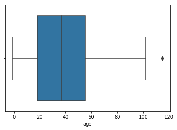

```python
sns.boxplot(df.age)
plt.show()
```

> Drawing boxplot to find outlier.A black spot can be observed .

```python
df[df.age > 100]
```

|  | patientid | appointmentid | gender | scheduledday | appointmentday | age | neighbourhood | scholarship | hypertension | diabetes | alcoholism | handicap | sms_received | no_show |
| --- | --- | --- | --- | --- | --- | --- | --- | --- | --- | --- | --- | --- | --- | --- |
| 58014 | 976294799775439 | 5651757 | F | 2016-05-03 | 2016-05-03 | 102 | CONQUISTA | 0 | 0 | 0 | 0 | 0 | 0 | 0 |
| 63912 | 31963211613981 | 5700278 | F | 2016-05-16 | 2016-05-19 | 115 | ANDORINHAS | 0 | 0 | 0 | 0 | 1 | 0 | 1 |
| 63915 | 31963211613981 | 5700279 | F | 2016-05-16 | 2016-05-19 | 115 | ANDORINHAS | 0 | 0 | 0 | 0 | 1 | 0 | 1 |
| 68127 | 31963211613981 | 5562812 | F | 2016-04-08 | 2016-05-16 | 115 | ANDORINHAS | 0 | 0 | 0 | 0 | 1 | 0 | 1 |
| 76284 | 31963211613981 | 5744037 | F | 2016-05-30 | 2016-05-30 | 115 | ANDORINHAS | 0 | 0 | 0 | 0 | 1 | 0 | 0 |
| 90372 | 234283596548 | 5751563 | F | 2016-05-31 | 2016-06-02 | 102 | MARIA ORTIZ | 0 | 0 | 0 | 0 | 0 | 0 | 0 |
| 97666 | 748234579244724 | 5717451 | F | 2016-05-19 | 2016-06-03 | 115 | SÃO JOSÉ | 0 | 1 | 0 | 0 | 0 | 1 | 0 |

Finding data with age greater than 100

```python
df[df.age <= 0]
```

|  | patientid | appointmentid | gender | scheduledday | appointmentday | age | neighbourhood | scholarship | hypertension | diabetes | alcoholism | handicap | sms_received | no_show |
| --- | --- | --- | --- | --- | --- | --- | --- | --- | --- | --- | --- | --- | --- | --- |
| 59 | 71844284745331 | 5638545 | F | 2016-04-29 | 2016-04-29 | 0 | CONQUISTA | 0 | 0 | 0 | 0 | 0 | 0 | 0 |
| 63 | 236623344873175 | 5628286 | M | 2016-04-27 | 2016-04-29 | 0 | SÃO BENEDITO | 0 | 0 | 0 | 0 | 0 | 0 | 0 |
| 64 | 188517384712787 | 5616082 | M | 2016-04-25 | 2016-04-29 | 0 | ILHA DAS CAIEIRAS | 0 | 0 | 0 | 0 | 0 | 1 | 0 |
| 65 | 271881817799985 | 5628321 | M | 2016-04-27 | 2016-04-29 | 0 | CONQUISTA | 0 | 0 | 0 | 0 | 0 | 0 | 0 |
| 67 | 86471282513499 | 5639264 | F | 2016-04-29 | 2016-04-29 | 0 | NOVA PALESTINA | 0 | 0 | 0 | 0 | 0 | 0 | 0 |
| 89 | 431493164159576 | 5640380 | M | 2016-04-29 | 2016-04-29 | 0 | MONTE BELO | 0 | 0 | 0 | 0 | 0 | 0 | 0 |
| 101 | 68228473371639 | 5642813 | M | 2016-04-29 | 2016-04-29 | 0 | BONFIM | 0 | 0 | 0 | 0 | 0 | 0 | 0 |
| 104 | 3326985214249 | 5632495 | F | 2016-04-28 | 2016-04-29 | 0 | SANTO ANTÔNIO | 0 | 0 | 0 | 0 | 0 | 0 | 1 |
| 132 | 846858655833146 | 5560742 | M | 2016-04-08 | 2016-04-29 | 0 | PRAIA DO SUÁ | 0 | 0 | 0 | 0 | 0 | 1 | 1 |
| 150 | 53924187266 | 5641476 | M | 2016-04-29 | 2016-04-29 | 0 | ITARARÉ | 0 | 0 | 0 | 0 | 0 | 0 | 0 |
| 188 | 188336557719787 | 5640933 | M | 2016-04-29 | 2016-04-29 | 0 | NOVA PALESTINA | 0 | 0 | 0 | 0 | 0 | 0 | 0 |
| 192 | 1165337725985 | 5640561 | M | 2016-04-29 | 2016-04-29 | 0 | CONQUISTA | 0 | 0 | 0 | 0 | 0 | 0 | 0 |
| 193 | 237969811161 | 5532452 | F | 2016-03-31 | 2016-04-29 | 0 | NOVA PALESTINA | 0 | 0 | 0 | 0 | 0 | 1 | 0 |
| 194 | 444253751531 | 5539566 | M | 2016-04-01 | 2016-04-29 | 0 | REDENÇÃO | 0 | 0 | 0 | 0 | 0 | 0 | 0 |
| 250 | 294272259913644 | 5640181 | M | 2016-04-29 | 2016-04-29 | 0 | CARATOÍRA | 0 | 0 | 0 | 0 | 0 | 0 | 1 |
| 256 | 85997128896 | 5629906 | F | 2016-04-27 | 2016-04-29 | 0 | ARIOVALDO FAVALESSA | 0 | 0 | 0 | 0 | 0 | 0 | 1 |
| 266 | 11981726819522 | 5639237 | M | 2016-04-29 | 2016-04-29 | 0 | MARIA ORTIZ | 0 | 0 | 0 | 0 | 0 | 0 | 0 |
| 292 | 46452376763692 | 5642766 | F | 2016-04-29 | 2016-04-29 | 0 | GURIGICA | 0 | 0 | 0 | 0 | 0 | 0 | 0 |
| 305 | 979481899122 | 5638226 | F | 2016-04-29 | 2016-04-29 | 0 | JOANA D´ARC | 0 | 0 | 0 | 0 | 0 | 0 | 0 |
| 306 | 264874564552 | 5638370 | M | 2016-04-29 | 2016-04-29 | 0 | SANTA MARTHA | 0 | 0 | 0 | 0 | 0 | 0 | 0 |
| 310 | 373237141336587 | 5639056 | M | 2016-04-29 | 2016-04-29 | 0 | SANTA MARTHA | 0 | 0 | 0 | 0 | 0 | 0 | 0 |
| 358 | 734926988844422 | 5531831 | F | 2016-03-31 | 2016-04-29 | 0 | CONSOLAÇÃO | 0 | 0 | 0 | 0 | 0 | 0 | 1 |
| 359 | 797528276177 | 5551583 | M | 2016-04-06 | 2016-04-29 | 0 | CONSOLAÇÃO | 0 | 0 | 0 | 0 | 0 | 0 | 0 |
| 366 | 349916676283616 | 5531933 | F | 2016-03-31 | 2016-04-29 | 0 | CONSOLAÇÃO | 0 | 0 | 0 | 0 | 0 | 1 | 1 |
| 377 | 912362654112 | 5522585 | M | 2016-03-29 | 2016-04-29 | 0 | DA PENHA | 0 | 0 | 0 | 0 | 0 | 1 | 0 |
| 434 | 962541679544459 | 5533985 | F | 2016-03-31 | 2016-04-29 | 0 | MORADA DE CAMBURI | 0 | 0 | 0 | 0 | 0 | 1 | 1 |
| 524 | 58153651796238 | 5488633 | M | 2016-03-18 | 2016-04-29 | 0 | ITARARÉ | 0 | 0 | 0 | 0 | 0 | 1 | 0 |
| 525 | 42392284266499 | 5537936 | F | 2016-04-01 | 2016-04-29 | 0 | ITARARÉ | 0 | 0 | 0 | 0 | 0 | 1 | 1 |
| 526 | 8574376259983 | 5639659 | M | 2016-04-29 | 2016-04-29 | 0 | ITARARÉ | 0 | 0 | 0 | 0 | 0 | 0 | 0 |
| 565 | 556989634224269 | 5591488 | F | 2016-04-15 | 2016-04-29 | 0 | SANTA LUÍZA | 0 | 0 | 0 | 0 | 0 | 1 | 0 |
| ... | ... | ... | ... | ... | ... | ... | ... | ... | ... | ... | ... | ... | ... | ... |
| 109629 | 36892216475853 | 5660428 | F | 2016-05-04 | 2016-06-01 | 0 | ROMÃO | 0 | 0 | 0 | 0 | 0 | 0 | 1 |
| 109633 | 36892216475853 | 5660427 | F | 2016-05-04 | 2016-06-01 | 0 | ROMÃO | 0 | 0 | 0 | 0 | 0 | 1 | 1 |
| 109646 | 59418113659912 | 5659194 | M | 2016-05-04 | 2016-06-01 | 0 | FORTE SÃO JOÃO | 0 | 0 | 0 | 0 | 0 | 0 | 0 |
| 109647 | 56352583933331 | 5691391 | M | 2016-05-12 | 2016-06-08 | 0 | FORTE SÃO JOÃO | 0 | 0 | 0 | 0 | 0 | 0 | 1 |
| 109649 | 59418113659912 | 5659193 | M | 2016-05-04 | 2016-06-01 | 0 | FORTE SÃO JOÃO | 0 | 0 | 0 | 0 | 0 | 0 | 0 |
| 109650 | 56352583933331 | 5691390 | M | 2016-05-12 | 2016-06-08 | 0 | FORTE SÃO JOÃO | 0 | 0 | 0 | 0 | 0 | 0 | 1 |
| 109830 | 693142925688 | 5739239 | F | 2016-05-25 | 2016-06-02 | 0 | SÃO BENEDITO | 0 | 0 | 0 | 0 | 0 | 0 | 1 |
| 109847 | 917448349946 | 5685977 | M | 2016-05-11 | 2016-06-02 | 0 | NOVA PALESTINA | 0 | 0 | 0 | 0 | 0 | 1 | 1 |
| 109848 | 5853539995282 | 5707361 | M | 2016-05-17 | 2016-06-02 | 0 | RESISTÊNCIA | 0 | 0 | 0 | 0 | 0 | 0 | 0 |
| 109852 | 16633164566722 | 5731578 | F | 2016-05-24 | 2016-06-02 | 0 | RESISTÊNCIA | 0 | 0 | 0 | 0 | 0 | 0 | 0 |
| 110231 | 173154797933633 | 5634706 | M | 2016-04-28 | 2016-06-01 | 0 | RESISTÊNCIA | 0 | 0 | 0 | 0 | 0 | 0 | 0 |
| 110235 | 327937315774645 | 5634274 | M | 2016-04-28 | 2016-06-01 | 0 | RESISTÊNCIA | 0 | 0 | 0 | 0 | 0 | 0 | 1 |
| 110236 | 11747165932598 | 5669996 | M | 2016-05-06 | 2016-06-08 | 0 | RESISTÊNCIA | 0 | 0 | 0 | 0 | 0 | 1 | 0 |
| 110299 | 59445133189 | 5746323 | F | 2016-05-30 | 2016-06-07 | 0 | RESISTÊNCIA | 0 | 0 | 0 | 0 | 0 | 1 | 1 |
| 110313 | 8535734345286 | 5600209 | F | 2016-04-19 | 2016-06-06 | 0 | RESISTÊNCIA | 0 | 0 | 0 | 0 | 0 | 1 | 0 |
| 110319 | 452418952997 | 5640301 | F | 2016-04-29 | 2016-06-06 | 0 | RESISTÊNCIA | 0 | 0 | 0 | 0 | 0 | 1 | 0 |
| 110320 | 34592678191648 | 5675103 | M | 2016-05-09 | 2016-06-06 | 0 | RESISTÊNCIA | 0 | 0 | 0 | 0 | 0 | 1 | 0 |
| 110321 | 138862971539 | 5338643 | M | 2016-02-11 | 2016-06-01 | 0 | RESISTÊNCIA | 0 | 0 | 0 | 0 | 0 | 1 | 0 |
| 110331 | 27394859494466 | 5392089 | F | 2016-02-24 | 2016-06-01 | 0 | RESISTÊNCIA | 0 | 0 | 0 | 0 | 0 | 1 | 1 |
| 110334 | 11747165932598 | 5756343 | M | 2016-06-01 | 2016-06-01 | 0 | RESISTÊNCIA | 0 | 0 | 0 | 0 | 0 | 0 | 0 |
| 110335 | 374795283286 | 5338761 | M | 2016-02-11 | 2016-06-01 | 0 | RESISTÊNCIA | 0 | 0 | 0 | 0 | 0 | 1 | 0 |
| 110339 | 3731746294837 | 5584042 | M | 2016-04-14 | 2016-06-01 | 0 | RESISTÊNCIA | 0 | 0 | 0 | 0 | 0 | 1 | 1 |
| 110341 | 4696832233511 | 5713894 | M | 2016-05-18 | 2016-06-01 | 0 | RESISTÊNCIA | 0 | 0 | 0 | 0 | 0 | 1 | 0 |
| 110342 | 314716274299 | 5776749 | M | 2016-06-06 | 2016-06-08 | 0 | RESISTÊNCIA | 0 | 0 | 0 | 0 | 0 | 0 | 0 |
| 110343 | 1759438895257 | 5690822 | F | 2016-05-12 | 2016-06-01 | 0 | RESISTÊNCIA | 0 | 0 | 0 | 0 | 0 | 1 | 0 |
| 110345 | 147395196662956 | 5702537 | F | 2016-05-16 | 2016-06-01 | 0 | RESISTÊNCIA | 0 | 0 | 0 | 0 | 0 | 0 | 0 |
| 110346 | 5577525313231 | 5777724 | M | 2016-06-06 | 2016-06-08 | 0 | RESISTÊNCIA | 0 | 0 | 0 | 0 | 0 | 0 | 0 |
| 110454 | 614245995575 | 5772400 | F | 2016-06-03 | 2016-06-03 | 0 | RESISTÊNCIA | 0 | 0 | 0 | 0 | 0 | 0 | 0 |
| 110460 | 43218463343323 | 5769545 | F | 2016-06-03 | 2016-06-03 | 0 | RESISTÊNCIA | 0 | 0 | 0 | 0 | 0 | 0 | 0 |
| 110507 | 476946211846992 | 5786918 | F | 2016-06-08 | 2016-06-08 | 0 | MARIA ORTIZ | 0 | 0 | 0 | 0 | 0 | 0 | 0 |

3540 rows × 14 columns

> The following data shows **youngest person** is -1 yrs old, which cannot be correct.So It would be Correct to drop these data for overall corectness.

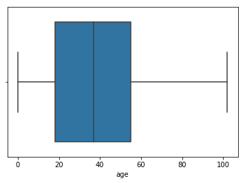

```python
# Triming the outliers
df = df[(df.age > -1) & (df.age < 115)]

# Looking into boxplot to verify the outcome
sns.boxplot(df.age)
plt.show()
```

> Removing Age outliers from the data frame to limit the outliers effect

```python
showed = df['no_show'] == 0
not_showed = df['no_show'] == 1
df['showed'] = showed
df['not_showed'] = not_showed
```

> Creating a mask

## Exploratory Data Analysis

### Percent of no_show

```
79.8083622117
```

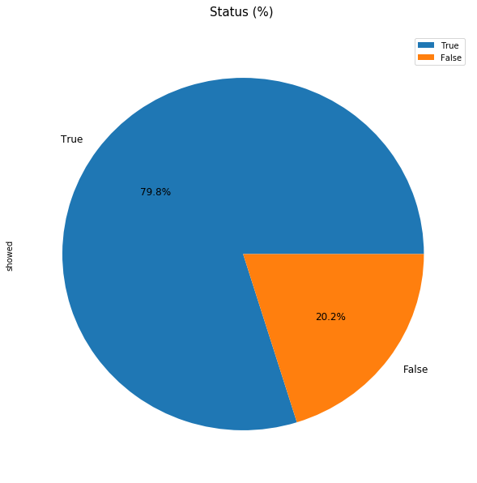

```python
allP = df['showed'].value_counts()
print(allP[1] / allP.sum() * 100)
pieChart = allP.plot.pie(figsize=(10,10), autopct='%1.1f%%', fontsize = 12);
pieChart.set_title("Status" + ' (%) \n', fontsize = 15);
plt.legend();
```

### What factors are important for us to know in order to predict if a patient will show up for their scheduled appointment?

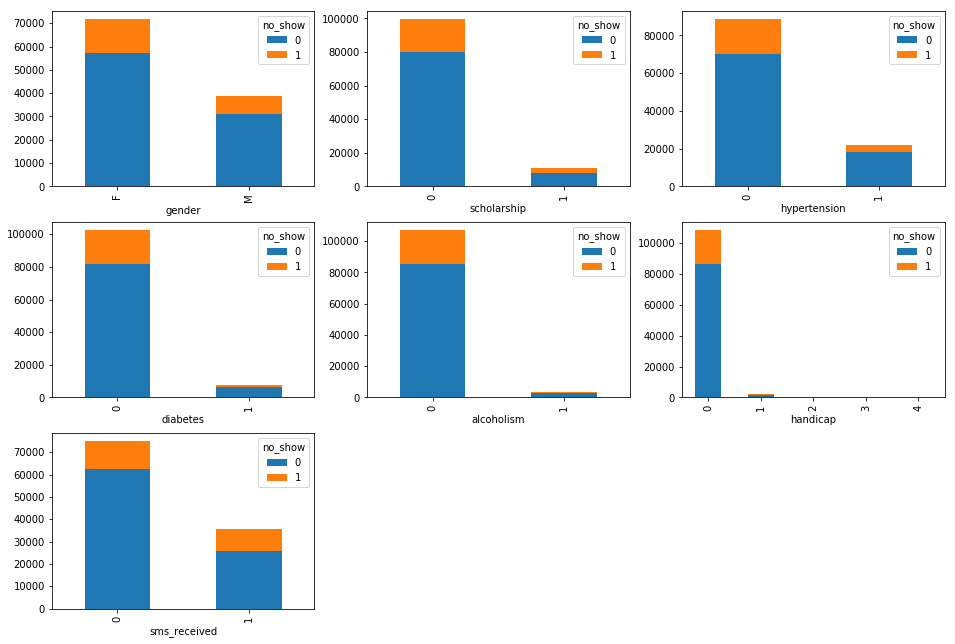

```python
new_vars = ['gender', 'scholarship', 'hypertension', 'diabetes', 'alcoholism', 'handicap', 'sms_received']

fig = plt.figure(figsize=(16, 11))
for i, var in enumerate(new_vars):
    ax = fig.add_subplot(3, 3, i+1)
    df.groupby([var, 'no_show'])[var].count().unstack('no_show').plot(ax=ax, kind='bar', stacked=True)
```

> **Features vs No-show bar charts:** Shows the change in No Show and show data with respect to features.

#### It can be easily noticed that there isn't any single feature with huge chages,Data is largly uniform.

### Does age play a role in No-Show?

> This chart shows Number of appointment for each range of age.

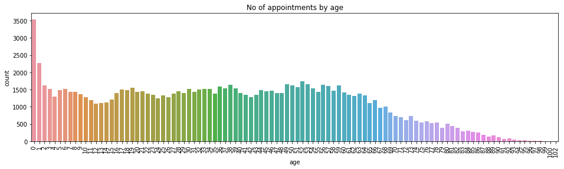

```python
plt.figure(figsize=(16,4))
plt.xticks(rotation=90)
ax = sns.countplot(x=df.age)
ax.set_title("No of appointments by age")
plt.show()
```

This chart shows Number of appointment for each age

### Does gender play a role?

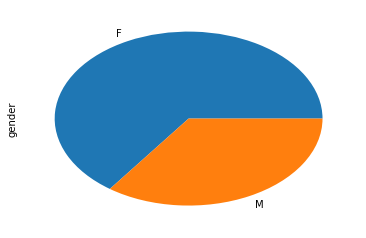

```python
df.gender.value_counts().plot(kind='pie')
```

Pie chart shows the number of male and female patients

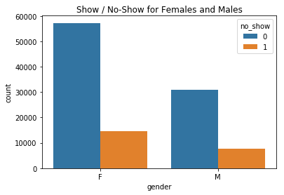

```python
ax = sns.countplot(x=df.gender, hue=df.no_show, data=df)
ax.set_title("Show / No-Show for Females and Males")
x_ticks_labels=['Female', 'Male']
plt.show();
```

> This bar chart shows the comprision between male and female with respect to Show/No_Show. We could not conclude any thing from here since data is largely uniform.

### Does location play a role?

> ‘Neighborhood’ indicates the location of the hospital.

```python
df['neighbourhood'].describe()
```

```
count             110521
unique                81
top       JARDIM CAMBURI
freq                7717
Name: neighbourhood, dtype: object
```

> There are 81 Hospitals altogether

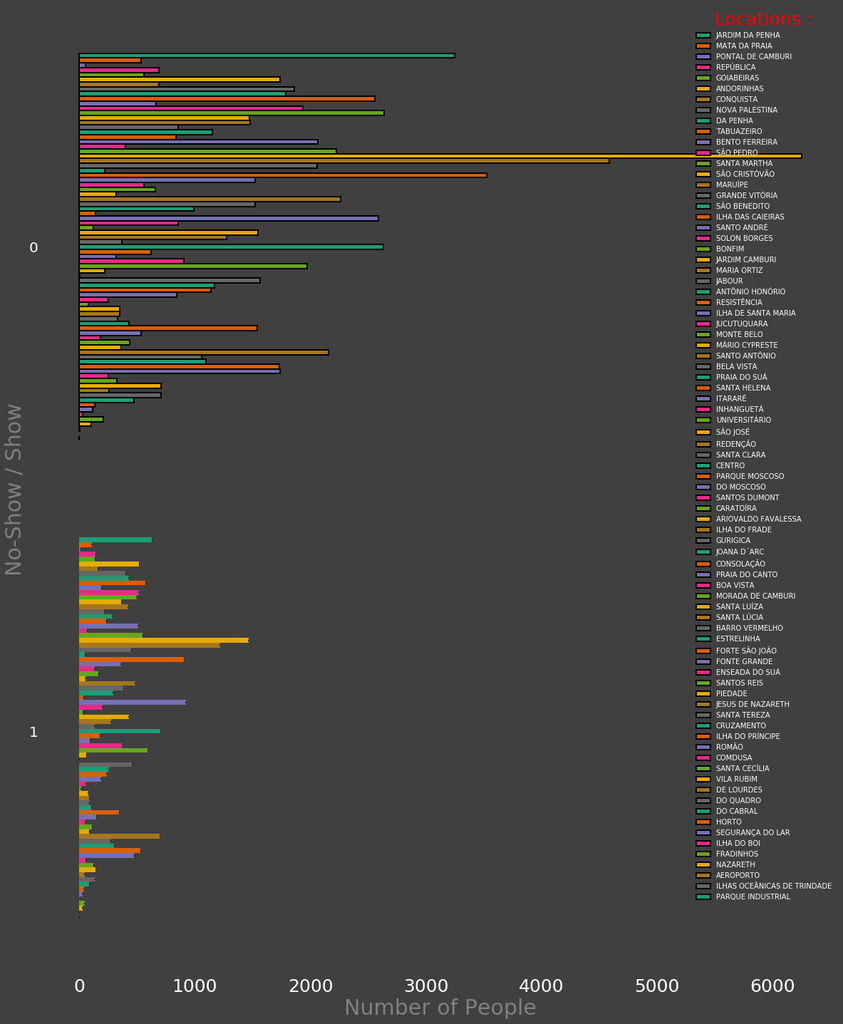

```python
bg_color = (0.25, 0.25, 0.25)
sns.set(rc={"font.style":"normal",
            "axes.facecolor":bg_color,
            "figure.facecolor":bg_color,
            "text.color":"White",
            "xtick.color":"White",
            "ytick.color":"White",
            "axes.labelcolor":"Grey",
            "axes.grid":False,
            'axes.labelsize':30,
            'figure.figsize':(20.0, 25.0),
            'xtick.labelsize':25,
            'ytick.labelsize':20})
num_categories = df.no_show.unique().size
p = sns.countplot(data=df,
                  y = df['no_show'],
                  hue=df['neighbourhood'],
                  saturation=1,
                  xerr=3*np.arange(num_categories),
                  edgecolor=(0,0,0),
                  linewidth=2,
                  palette="Dark2")
plt.ylabel("No-Show / Show")
plt.xlabel("Number of People")
l = p.get_legend()
l.set_title("Locations :")
l.get_title().set_color('Red')
```

> The above figure represents number of patient showed up or didn't showed up for **81 hospitals**

#### It shows great difference in no_show proportion.

## Conclusions

**Limitation :**

> There were some missing features that could have been more useful such as if the patient is employeed or not , or whether the patient have a series medical issue's or not. Data was also not super accurate like people can't have age as '-1'.

```python
from subprocess import call
call(['python', '-m', 'nbconvert', 'Investigate_a_Dataset.ipynb'])
```